# Fitbit & ET Glasses - Methods

# Initial Preparations

Run following Code if and only if new data is added to the initial data.

# ET Glasses

## Acceleration

The Tobii Glases record acceleration data with a frequency of 100Hz. Therefore it should be possible to calculate the walked distance wearing the glasses using the following formulas:

$$\Delta x_{d,i} = 0.5 (t_{i-1}-t_{i})^2,
\text{ with }i=2,...,t_n; d = z,x$$

$$x_d=\sum_{i=1}^n |\Delta x_{d,i}|,
\text{ with }i=2,...,t_n; d = z,x$$

$$\sum x=\sqrt{x_z^2+x_x^2}$$

Using these formulas, one brave assumption must be made, that is, for every time period the initial velocity is equal to 0.

The real data gives plausible values.

| ID | meter_x | meter_z | ges |
| --- | --- | --- | --- |
| 101 | 10.013991 | 11.567138 | 15.299631 |
| 102 | 7.993025 | 14.470191 | 16.531028 |
| 103 | 7.011442 | 17.430047 | 18.787412 |
| 104 | 5.084440 | 7.128522 | 8.755990 |
| 105 | 9.921173 | 13.105560 | 16.437317 |
| 106 | 8.612761 | 18.498108 | 20.404893 |
| 107 | 8.435554 | 9.493887 | 12.700097 |
| 108 | 5.895645 | 8.007376 | 9.943676 |
| 109 | 9.692427 | 8.748062 | 13.056483 |
| 201 | 6.072159 | 7.075609 | 9.323913 |

[output cut: 2 more lines]

```
   Min. 1st Qu.  Median    Mean 3rd Qu.    Max.
  8.756  12.011  15.412  14.769  17.095  20.468
```

On the contrary, simulated situations revealed multiple problems.

For the first simulation the participant was standing still without moving its head and with strong movements of the head respectively. A reliable measurement would give the same distance for both situations. Afterwards, we simulated two two times 5 meter long walks. One time the participant turned around after 5 meters. During the other walk the participant walked 5 meters and walked back backwards. Again, we expect the glasses to give the same walking distance. To test real world situations we simulated two random walks in a simulated class room. One walk simulated an extensive walk and the other walk simulated a less intense walk. Additionally, we tested the values for taking the elevator and walking a staircase. The simulated situations give the following values.

| ID | meter_x | meter_z | ges |
| --- | --- | --- | --- |
| elevator | 0.52665382 | 1.2140842 | 1.3233913 |
| still_w_head | 0.62801902 | 1.5839472 | 1.7039063 |
| still_wo_head | 0.40343856 | 0.6200339 | 0.7397329 |
| walk_rand_two_minutes | 0.47267591 | 1.6457786 | 1.7123112 |
| walk_random_two_min_less | 0.51046844 | 1.8331157 | 1.9028640 |
| walk_stairs | 0.54745267 | 1.4668428 | 1.5656731 |
| walk_ten_met_w_turn | 0.09590711 | 0.1724256 | 0.1973037 |
| walk_ten_met_wo_turn | 0.06115748 | 0.3364277 | 0.3419412 |

Plotting the acceleration reveals the problems with the acceleration data.

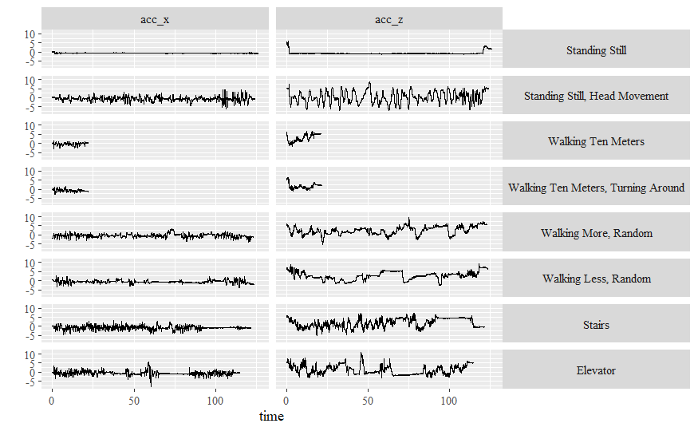

## Pupil Dialation

The ET Glasses report the pupil dilation at a frequency of 100 Hz.

# FitBit

All participants were given a FitBit Smart Watch to wear during the experiment.

## Heart Rate

The heart rate of each participant were measured during the experiment.

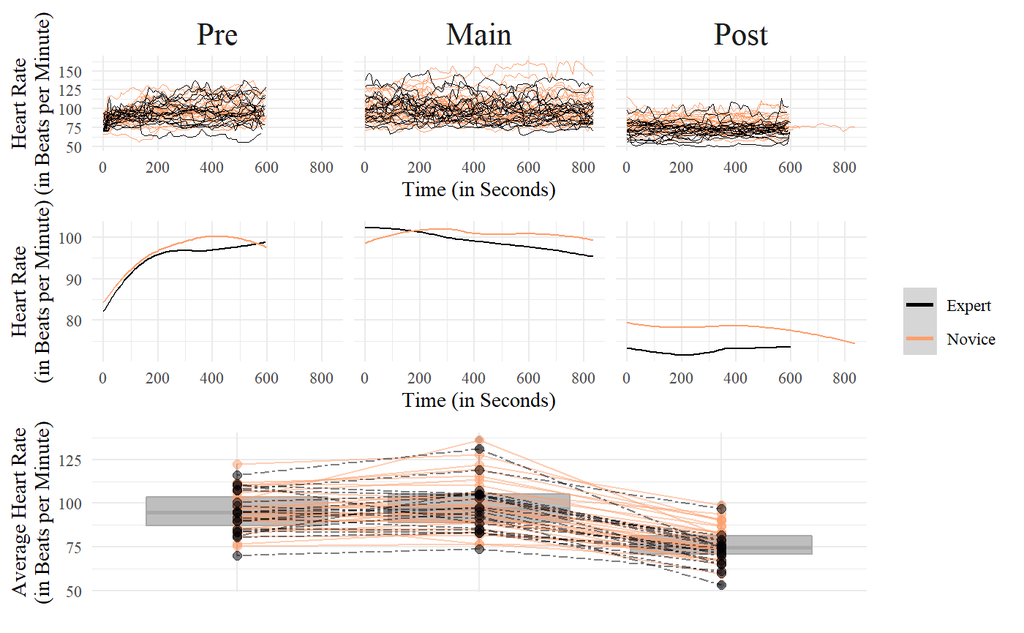

[output not shown]

## Steps

Using the FitBit we could also measure the steps a person walked. Unfortunately, the measurement was not as reliable as hoped. To confirm, we should simulate situations with a fixed number of steps.

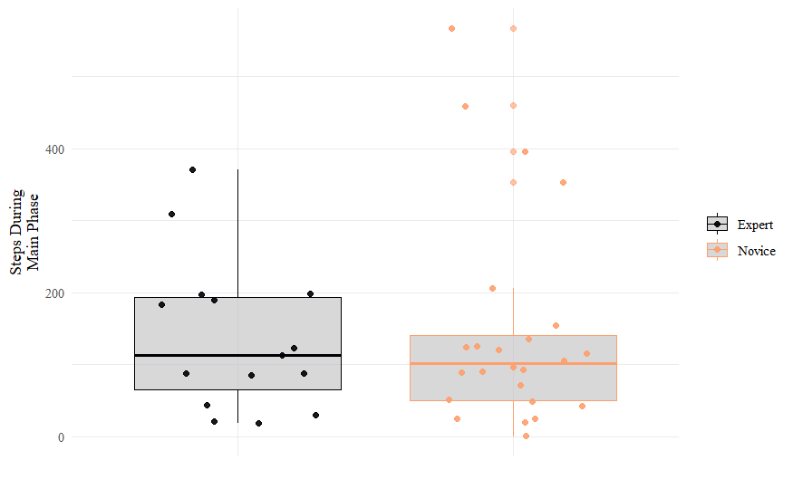

| ID | mean | Steps | type |
| --- | --- | --- | --- |
| 207 | 102.54404 | 309 | Expert |
| 122 | 94.38333 | 206 | Novice |
| 109 | 89.39375 | 116 | Novice |
| 202 | 73.84472 | 371 | Expert |
| 208 | 93.16062 | 88 | Expert |
| 105 | 89.80714 | 106 | Novice |

# Combined Analysis

## Steps and Heart Rate

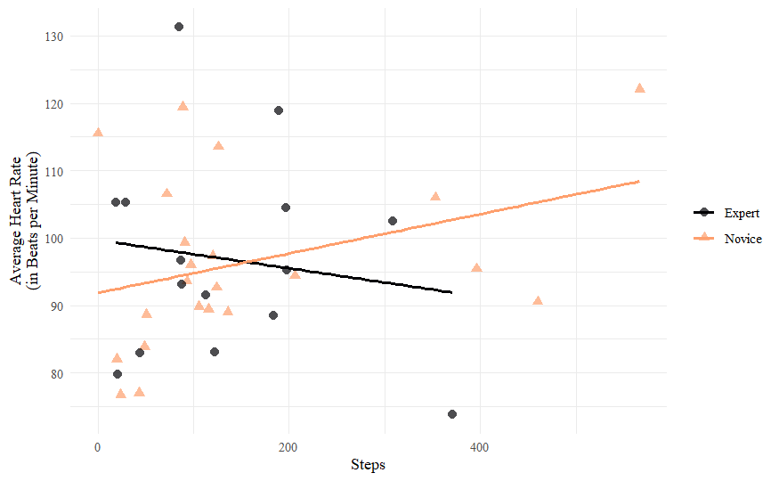

## Heart Rate and Pupil Dilation

```
Warning: Removed 7158 rows containing non-finite values (stat_smooth).
Warning: Removed 7158 rows containing missing values (geom_point).
```

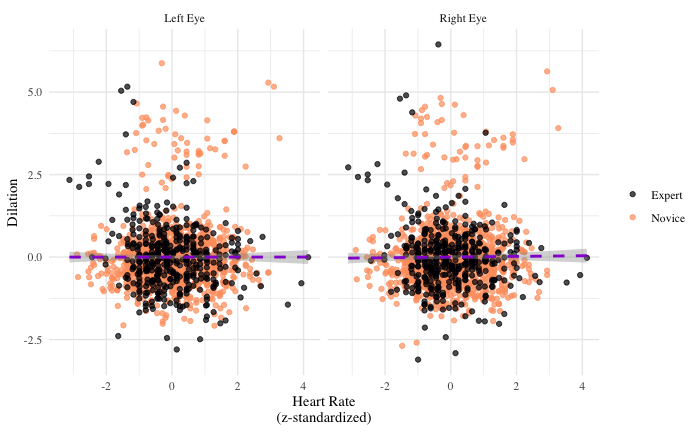

# Measuring

[figure not shown]